# Prediction Assignment Writeup

Arjen Hunter

11 January 2019

## Method used

The data that was made available for this project, consists of a training dataset and a testing dataset. Here is the method we have used:

1. Loading the data set;
2. Split the data;
3. Cleaning the data;
4. Look for covariance;
5. Build a model;
6. Verify the model;
7. Apply the model;

## Loading the data.

First of all we must set the seed and load all required libraries.

Then we load the data set and eyeball the characteristics of the data. Most of the exploratory data analysis is not shown here. It was performed using the DataExplorer package. A package that automatically scans through the data and does data profiling, reporting the results in a separate file.

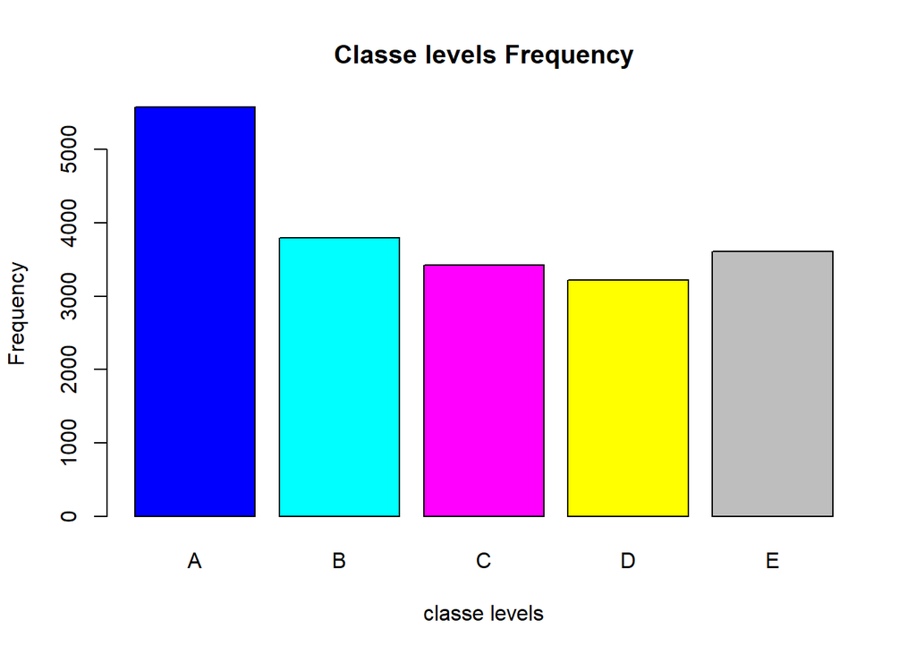

```r
train = read.csv("C:/Users/User/Documents/coursera/pml-training.csv")
testcases = read.csv("C:/Users/User/Documents/coursera/pml-testing.csv")
## Eyeball classe variable
plot(train$classe,ylab="Frequency",
     xlab="classe levels",
     main="Classe levels Frequency",
     col=c(12,13,14,15,16))
```

In the Classe levels plot we see that there are 5 levels to the classe label and all five levels have a substantial amount of measurement. Some of the data may be missing (NA).

```r
sum(sapply(train, function(x) mean(is.na(x))) > 0.95)
```

```
## [1] 67
```

The dataset contains 67 labels with ?95% of NA’s and potentially a number of labels with very little variance.

```r
x  <-  nearZeroVar(train)
```

A total of 51 labels contain very little variance. Including those labels would increase the risk of overfitting the model, resulting in a unnecessarily large out of sample error when applying the model to predictions. Since both high level of NA and low variance will be removed from the dataset that we’ll be building our model upon, the overlap between the two groups is of no interest to us.

## Split the data

[output not shown]

```r
inTrain  <- createDataPartition(train$classe, p=0.7, list=FALSE)
train <- train[inTrain, ]
test  <- train[-inTrain, ]
```

## Cleaning the data

The training data contains 160 labels. We need to clean the data by

1. excluding labels containing mostly NA (i.e. empty cells);
2. excluding variables which have little variation;

Note there are 3 sets of data that must be subjected to the same cleaning procedure, the training data, the testing data and the testcase data sets. The cleaning procedure is determined on the trainingset alone, whereas it is applied to all three sets.

```r
## cleaining the data, remove columns with >95% NA.
x <- sapply(train, function(x) mean(is.na(x))) > 0.95
train <- train[, x==FALSE]
test  <- test[, x==FALSE]
testcases  <- testcases[, x==FALSE]

## remove near zero variation.
x  <-  nearZeroVar(train)
if(length(x) > 0) train <- train[, -x]
if(length(x) > 0) test <- test[, -x]
if(length(x) > 0) testcases <- testcases[, -x]

## remove non-numeric columns and the first column with serial number.
train <-train[, -(1:5)]
test <-test[, -(1:5)]
testcases <-testcases[, -(1:5)]
```

We now have removed labels containing more than 95% of NA, labels having very little variation and the first 5 columns, containing labels that are not usefull in this analysis. Such as names and dates.

## Look for covariance

By building a correlation matrix we show the level of covariance in the data. If many labels are highly correlated, they will negatively influence the model. Perform Principle Component Analysis will be used to further reduce the number of variables.

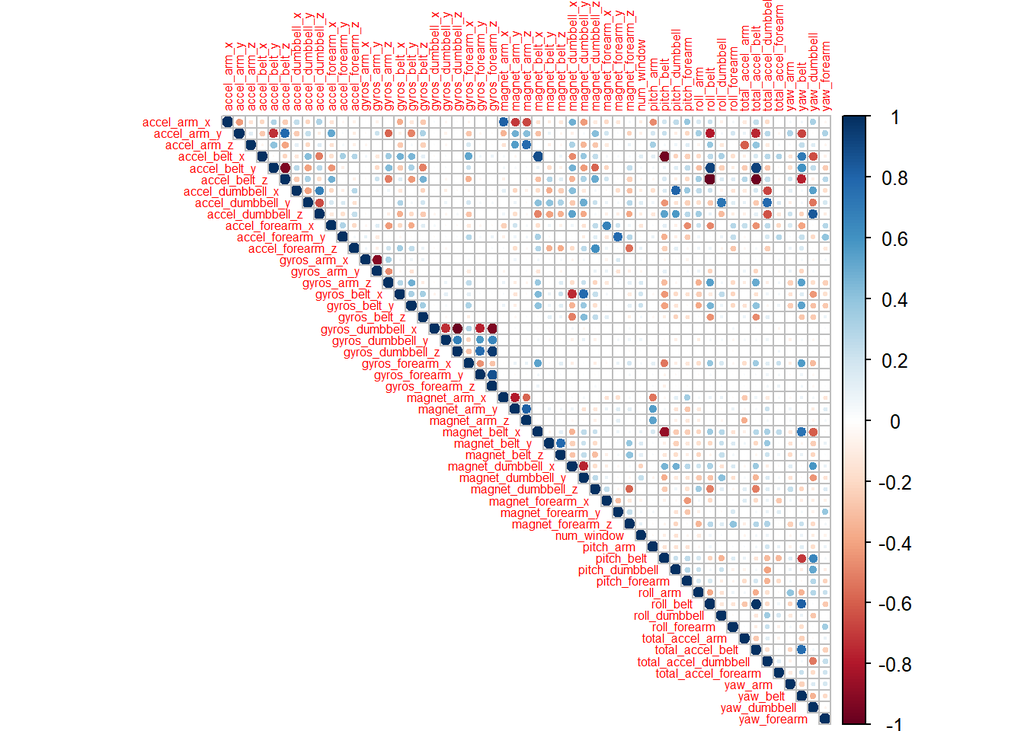

```r
## correlation analysis, note col 54 is out Y called classe
corMatrix <- cor(train[, -54])
corrplot(corMatrix, order = "alphabet", type = "upper", tl.cex = 0.5)
```

As can be seen in the correlation matrix, there is a number of significant correlations within the dataset, so is makes sense to perform PCA.

```r
preProc <- preProcess(train[,1:53],method="pca",thresh=.95)
```

The pre-processed model now stored in preProc was created from 13737 samples and 53 variables. PCA uses 25 components to capture 95 percent of the variance.

## Build a model

Build a model using the random forest method using the pre-processed training set.

```r
trainingPC <- predict(preProc,train[,1:53])
FitRF <- randomForest(train$classe ~ ., data=trainingPC, do.trace=F)
confusionMatrix(train$classe,predict(FitRF,trainingPC))
```

```
## Confusion Matrix and Statistics
##
##           Reference
## Prediction    A    B    C    D    E
##          A 3906    0    0    0    0
##          B    0 2658    0    0    0
##          C    0    0 2396    0    0
##          D    0    0    0 2252    0
##          E    0    0    0    0 2525
##
## Overall Statistics
##
##                Accuracy : 1
##                  95% CI : (0.9997, 1)
##     No Information Rate : 0.2843
##     P-Value [Acc > NIR] : < 2.2e-16
##
##                   Kappa : 1
##  Mcnemar's Test P-Value : NA
##
## Statistics by Class:
##
##                      Class: A Class: B Class: C Class: D Class: E
## Sensitivity            1.0000   1.0000   1.0000   1.0000   1.0000
## Specificity            1.0000   1.0000   1.0000   1.0000   1.0000
## Pos Pred Value         1.0000   1.0000   1.0000   1.0000   1.0000
## Neg Pred Value         1.0000   1.0000   1.0000   1.0000   1.0000
## Prevalence             0.2843   0.1935   0.1744   0.1639   0.1838
## Detection Rate         0.2843   0.1935   0.1744   0.1639   0.1838
## Detection Prevalence   0.2843   0.1935   0.1744   0.1639   0.1838
## Balanced Accuracy      1.0000   1.0000   1.0000   1.0000   1.0000
```

Here we see our model has achieved a very high accuracy 95% CI : (0.9997, 1). The confidence interval includes 1. Note the complete separation in the selection matrix, there are no errors. Which is confirmed by the perfect sensitivity and specificity for all levels of classe.

## Verify the model

Verify the model with the testing data set

```r
testingPC <- predict(preProc,test[,1:53])
confusionMatrix(test$classe,predict(FitRF,testingPC))
```

```
## Confusion Matrix and Statistics
##
##           Reference
## Prediction    A    B    C    D    E
##          A 1162    0    0    0    0
##          B    0  792    0    0    0
##          C    0    0  742    0    0
##          D    0    0    0  673    0
##          E    0    0    0    0  753
##
## Overall Statistics
##
##                Accuracy : 1
##                  95% CI : (0.9991, 1)
##     No Information Rate : 0.2819
##     P-Value [Acc > NIR] : < 2.2e-16
##
##                   Kappa : 1
##  Mcnemar's Test P-Value : NA
##
## Statistics by Class:
##
##                      Class: A Class: B Class: C Class: D Class: E
## Sensitivity            1.0000   1.0000     1.00   1.0000   1.0000
## Specificity            1.0000   1.0000     1.00   1.0000   1.0000
## Pos Pred Value         1.0000   1.0000     1.00   1.0000   1.0000
## Neg Pred Value         1.0000   1.0000     1.00   1.0000   1.0000
## Prevalence             0.2819   0.1921     0.18   0.1633   0.1827
## Detection Rate         0.2819   0.1921     0.18   0.1633   0.1827
## Detection Prevalence   0.2819   0.1921     0.18   0.1633   0.1827
## Balanced Accuracy      1.0000   1.0000     1.00   1.0000   1.0000
```

## Apply the model

Apply the model to estimate classes of 20 observations

```r
testdataPC <- predict(preProc,testcases[,1:53])
testcases$classe <- predict(FitRF,testdataPC)
testcases$classe
```

```
##  [1] B A B A A E D B A A B C B A E E A B B B
## Levels: A B C D E
```

## Summary and conclusion

The data for this project come from this source: http://web.archive.org/web/20161224072740/http:/groupware.les.inf.puc-rio.br/har. If you use the document you create for this class for any purpose please cite them as they have been very generous in allowing their data to be used for this kind of assignment.